# Gao_eco5316_HW5

Shijia Gao

3/11/2019

```r
# install.packages("tibbletime")
# install.packages("uroot")
# install.packages ("tseries")
# install.packages("urca")

library(tidyquant)
library(timetk)
library(tibbletime)
library(broom)
library(sweep)
library(ggplot2)
library(scales)
library(ggfortify)
library(egg)
library(tsibble)
library(tictoc)
library(forecast)
library(tseries)
library(uroot)
library(urca)


# set default theme for ggplot2
theme_set(theme_bw())
```

1. Obtain monthly data for Total Nonfarm Payroll Employment, Not Seasonally Adjusted, available on FRED under code [`PAYNSA`]https://fred.stlouisfed.org/series/PAYNSA(). Import the 1975M1-2018M12 sample using `tq_get`. &
2. Construct the following transformed time series
1. change in Total Nonfarm Payroll Employment $\Delta E_t = E_t - E_{t-1}$
2. log of Total Nonfarm Payroll Employment $\log E_t$
3. log change in Total Nonfarm Payroll Employment $\Delta \log E_t = \log E_t - \log E_{t-1}$
4. 12 month log change in Total Nonfarm Payroll Employment $\Delta_{12} \log E_t = \log E_t - \log E_{t-12}$
5. twice differenced Total Nonfarm Payroll Employment $\Delta \Delta_{12} \log E_t = \Delta_{12} \log E_t - \Delta_{12} \log E_{t-1}$.

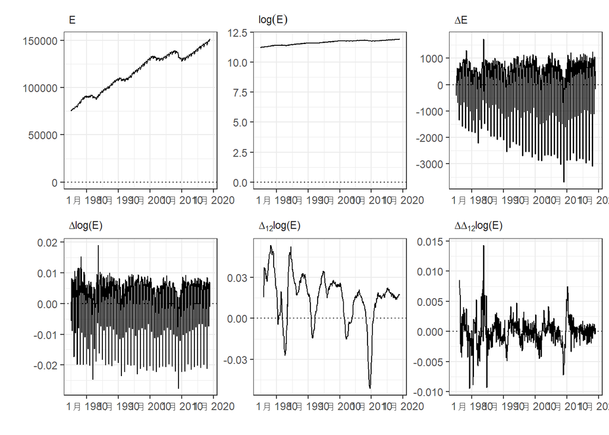

```r
data.tbl <-
  tq_get("PAYNSA", get = "economic.data", from = "1975-01-01", to = "2018-12-01")  %>%
  rename(E = price) %>%
  ts(start = c(1975,1), frequency = 12) %>%
  tk_tbl() %>%
  mutate(lE = log(E),
         dE = E - lag(E),
         dlE1 = lE - lag(lE),
         dlE12 = lE - lag(lE, 12),
         d2lE12_1 = dlE12 - lag(dlE12))


#Plot the original and the transformed time series. Comment on their trends, volatility, seasonal patterns.
fstm <- 1975.00
lstm <- 2019-(1/12)
data_tbl_1 <- data.tbl %>%
  filter(index <= as.yearmon(lstm))

data_tbl_1%>%
  gather(variable, value, -index,-date) %>%
  mutate(variable_label = factor(variable, ordered = TRUE,
                                 levels = c("E", "lE", "dE", "dlE1", "dlE12", "d2lE12_1"),
                                 labels = c("E", "log(E)",
                                            expression(paste(Delta,"E")),
                                            expression(paste(Delta,"log(E)")),
                                            expression(paste(Delta[12],"log(E)")),
                                            expression(paste(Delta,Delta[12],"log(E)"))))) %>%
  ggplot(aes(x = index, y = value)) +
  geom_hline(aes(yintercept = 0), linetype = "dotted") +
  geom_line() +
  scale_x_yearmon() +
  labs(x = "", y = "") +
  facet_wrap(~variable_label, ncol = 3, scales = "free", labeller = label_parsed) +
  theme(strip.text = element_text(hjust = 0),
        strip.background = element_blank())
```

Comments: From the above graphs, we can see the original monthly data for Total Nonfarm Payroll Employment is nonstationary, it shows some seasonal pattern and increasing trend, so we have to transform the data using a logarithm and apply both regular and seasonal differencing, namely d2lE12_1 = dlE12 - lag(dlE12), from the graph of d2LE12_1, we can see the data is roughly stationary around the mean of 0, which means the increasing trend is also removed.

3. Use `ggseasonplot` to create seasonal plots for $\Delta E_t$ and $\Delta \log E_t$. Comment on the seasonal patterns.

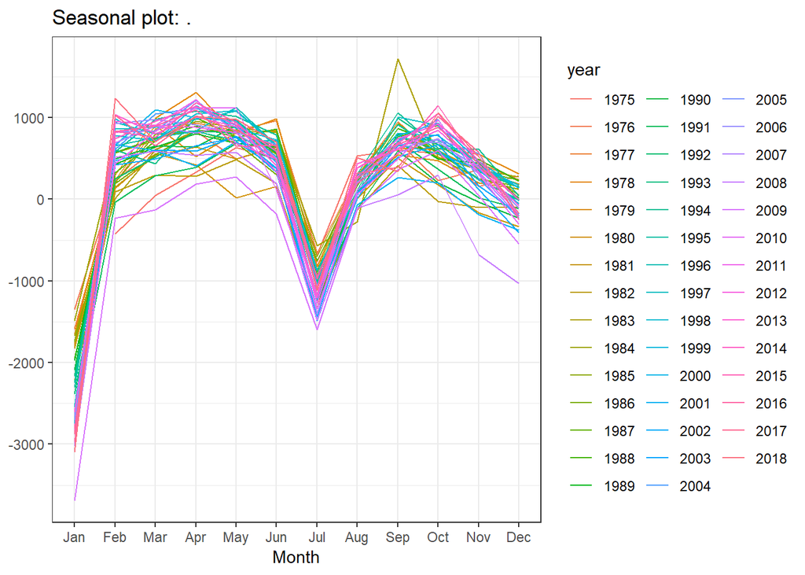

```r
data_tbl_1%>% tk_ts(select=dE, start=c(1975 ,1),frequency=12)%>% ggseasonplot
```

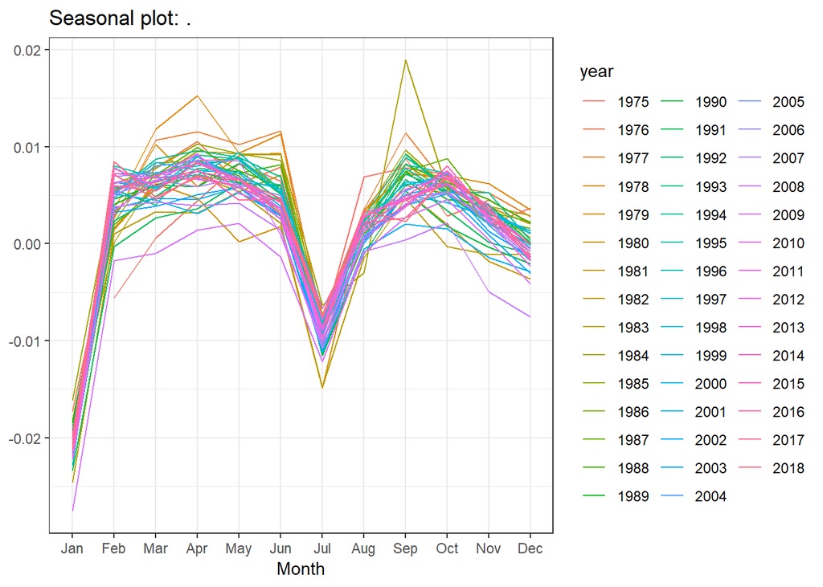

```r
data_tbl_1%>% tk_ts(select=dlE1, start=c(1975,1),frequency=12)%>% ggseasonplot
```

Comments: From the follwing graph, both $\Delta E_t$ and $\Delta \log E_t$ had shown seasonality pattern almost every 12months .

4. Plot ACF and PACF for $\log E_t, \Delta \log E_t, \Delta_{12} \log E_t, \Delta \Delta_{12} \log E_t$. Comment on their shape.

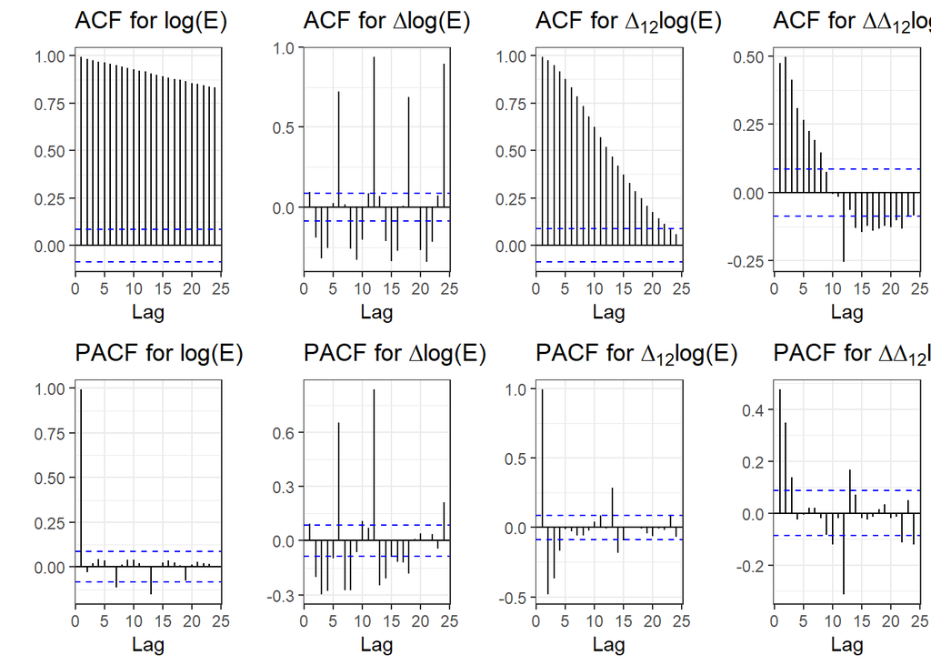

```r
maxlag <-24
g1 <- data_tbl_1  %>% pull(lE) %>% ggAcf(lag.max = maxlag, ylab = "", main = expression(paste("ACF for log(E)")))
g2 <- data_tbl_1  %>% pull(dlE1) %>% ggAcf(lag.max = maxlag, ylab = "", main = expression(paste("ACF for ", Delta,"log(E)")))
g3 <- data_tbl_1  %>% pull(dlE12) %>% ggAcf(lag.max = maxlag, ylab = "", main = expression(paste("ACF for ", Delta[12], "log(E)")))
g4 <- data_tbl_1  %>% pull(d2lE12_1) %>% ggAcf(lag.max = maxlag, ylab = "", main = expression(paste("ACF for ", Delta, Delta[12], "log(E)")))
g5 <- data_tbl_1  %>% pull(lE) %>% ggPacf(lag.max = maxlag, ylab = "", main = expression(paste("PACF for log(E)")))
g6 <- data_tbl_1  %>% pull(dlE1) %>% ggPacf(lag.max = maxlag, ylab = "", main = expression(paste("PACF for ", Delta, "log(E)")))
g7 <- data_tbl_1  %>% pull(dlE12) %>% ggPacf(lag.max = maxlag, ylab = "", main = expression(paste("PACF for ", Delta[12], "log(E)")))
g8 <- data_tbl_1 %>% pull(d2lE12_1) %>% ggPacf(lag.max = maxlag, ylab = "", main = expression(paste("PACF for ", Delta,Delta[12], "log(E)")))

ggarrange(g1, g2, g3, g4, g5, g6, g7, g8, ncol = 4)
```

Comments: For log E_t, it shows a gradual decline in the ACF and a spike which almost equals to 1 at first lag in the PACF, so there is a unit root. For Delta E_t, the first large spike in the ACF of log E_t has gone now, which is good, but there are some spikes at lag6, lag 12, lag18, lag24, and in the PACF, spikes are at lag6, lag 12, so there must be some seasonal pattern, and it’s more like multiplicative seasonal MA model. For Delta_{12} E_t, it’s like AR(3) model. For Delta _{12} E_t, There is a gradual decline every 12 lags in ACF, and in PACF, there are some large spikes in lag 1, lag2, lag3 and lag12, and small spikes in lag 13, lag 14 and lag 24, so we can estimate that the model is AR(3) with seasonal pattern, the frequency is 12, namely the model might be ARIMA(3,0,0)(3,0,0)[12], and we can estimate it later.

5. Perform the ADF and KPSS tests on $\log E_t, \Delta_{12} \log E_t, \Delta \Delta_{12} \log E_t$. Summarize the results.

```r
data.ts1 <- data.tbl %>%
  tk_ts(select = lE, start = fstm, frequency = 12)
ur.df(data.ts1,type="drift", selectlags="AIC")%>%summary()
```

```
##
## ###############################################
## # Augmented Dickey-Fuller Test Unit Root Test #
## ###############################################
##
## Test regression drift
##
##
## Call:
## lm(formula = z.diff ~ z.lag.1 + 1 + z.diff.lag)
##
## Residuals:
##        Min         1Q     Median         3Q        Max
## -0.0274693 -0.0007889  0.0025391  0.0050885  0.0171314
##
## Coefficients:
##              Estimate Std. Error t value Pr(>|t|)
## (Intercept)  0.043563   0.022492   1.937   0.0533 .
## z.lag.1     -0.003636   0.001930  -1.884   0.0601 .
## z.diff.lag   0.090564   0.043391   2.087   0.0374 *
## ---
## Signif. codes:  0 '***' 0.001 '**' 0.01 '*' 0.05 '.' 0.1 ' ' 1
##
## Residual standard error: 0.008137 on 523 degrees of freedom
## Multiple R-squared:  0.01544,    Adjusted R-squared:  0.01167
## F-statistic:   4.1 on 2 and 523 DF,  p-value: 0.0171
##
##
## Value of test-statistic is: -1.8841 7.2755
##
## Critical values for test statistics:
##       1pct  5pct 10pct
## tau2 -3.43 -2.86 -2.57
## phi1  6.43  4.59  3.78
```

```r
ur.kpss(data.ts1,type="mu", lags="long")%>%summary()
```

```
##
## #######################
## # KPSS Unit Root Test #
## #######################
##
## Test is of type: mu with 18 lags.
##
## Value of test-statistic is: 2.7416
##
## Critical value for a significance level of:
##                 10pct  5pct 2.5pct  1pct
## critical values 0.347 0.463  0.574 0.739
```

```r
data.ts2 <- na.omit(data.tbl) %>%
  tk_ts(select = dlE12, start = fstm, frequency = 12)
  ur.df(data.ts2,type="drift", selectlags="AIC")%>%summary()
```

```
##
## ###############################################
## # Augmented Dickey-Fuller Test Unit Root Test #
## ###############################################
##
## Test regression drift
##
##
## Call:
## lm(formula = z.diff ~ z.lag.1 + 1 + z.diff.lag)
##
## Residuals:
##        Min         1Q     Median         3Q        Max
## -0.0116071 -0.0010818  0.0000531  0.0010554  0.0149869
##
## Coefficients:
##               Estimate Std. Error t value Pr(>|t|)
## (Intercept)  0.0001820  0.0001201   1.516  0.13009
## z.lag.1     -0.0131821  0.0050658  -2.602  0.00953 **
## z.diff.lag   0.4719830  0.0385604  12.240  < 2e-16 ***
## ---
## Signif. codes:  0 '***' 0.001 '**' 0.01 '*' 0.05 '.' 0.1 ' ' 1
##
## Residual standard error: 0.002074 on 510 degrees of freedom
## Multiple R-squared:  0.2309, Adjusted R-squared:  0.2279
## F-statistic: 76.57 on 2 and 510 DF,  p-value: < 2.2e-16
##
##
## Value of test-statistic is: -2.6022 3.4096
##
## Critical values for test statistics:
##       1pct  5pct 10pct
## tau2 -3.43 -2.86 -2.57
## phi1  6.43  4.59  3.78
```

```r
  ur.kpss(data.ts2,type="mu", lags="long")%>%summary()
```

```
##
## #######################
## # KPSS Unit Root Test #
## #######################
##
## Test is of type: mu with 18 lags.
##
## Value of test-statistic is: 0.4387
##
## Critical value for a significance level of:
##                 10pct  5pct 2.5pct  1pct
## critical values 0.347 0.463  0.574 0.739
```

```r
data.ts3 <- na.omit(data.tbl) %>%
  tk_ts(select = d2lE12_1, start = fstm, frequency = 12)
  ur.df(data.ts3,type="drift", selectlags="AIC")%>%summary()
```

```
##
## ###############################################
## # Augmented Dickey-Fuller Test Unit Root Test #
## ###############################################
##
## Test regression drift
##
##
## Call:
## lm(formula = z.diff ~ z.lag.1 + 1 + z.diff.lag)
##
## Residuals:
##        Min         1Q     Median         3Q        Max
## -0.0106525 -0.0010372  0.0000102  0.0010128  0.0117649
##
## Coefficients:
##               Estimate Std. Error t value Pr(>|t|)
## (Intercept) -2.388e-05  8.591e-05  -0.278    0.781
## z.lag.1     -3.513e-01  4.170e-02  -8.424 3.71e-16 ***
## z.diff.lag  -3.570e-01  4.067e-02  -8.777  < 2e-16 ***
## ---
## Signif. codes:  0 '***' 0.001 '**' 0.01 '*' 0.05 '.' 0.1 ' ' 1
##
## Residual standard error: 0.001946 on 510 degrees of freedom
## Multiple R-squared:  0.3674, Adjusted R-squared:  0.3649
## F-statistic: 148.1 on 2 and 510 DF,  p-value: < 2.2e-16
##
##
## Value of test-statistic is: -8.4245 35.5197
##
## Critical values for test statistics:
##       1pct  5pct 10pct
## tau2 -3.43 -2.86 -2.57
## phi1  6.43  4.59  3.78
```

```r
  ur.kpss(data.ts3,type="mu", lags="long")%>%summary()
```

```
##
## #######################
## # KPSS Unit Root Test #
## #######################
##
## Test is of type: mu with 18 lags.
##
## Value of test-statistic is: 0.0241
##
## Critical value for a significance level of:
##                 10pct  5pct 2.5pct  1pct
## critical values 0.347 0.463  0.574 0.739
```

6. Split the sample into two parts: estimation sample from 1975M1 to 2014M12, and prediction sample from 2015M1 to 2018M12. Use ACF and PACF from (c) to identify and estimate a suitable model for $\Delta \Delta_{12} \log E_t$ using `Arima`. Check the estimated model for adequacy - diagnose residuals using `ggtsdiag`

```r
# split sample - estimation and prediction subsamples
fstm1 <- 1975.000
lstm1 <- 2015-(1/12)
fstm2 <- 2015.000
lstm2 <- 2019-(1/12)

##Use ACF and PACF from (d), we can identify and estimate a suitable model is ARIMA(3,0,0)(3,0,0)[12]
me<- data_tbl_1 %>%
  tk_ts(select = d2lE12_1, start = fstm1, frequency = 12) %>%
  Arima(order = c(3,0,0), seasonal = list(order = c(3,0,0), period = 12))
  ggtsdiag(me, gof.lag = maxlag)
```

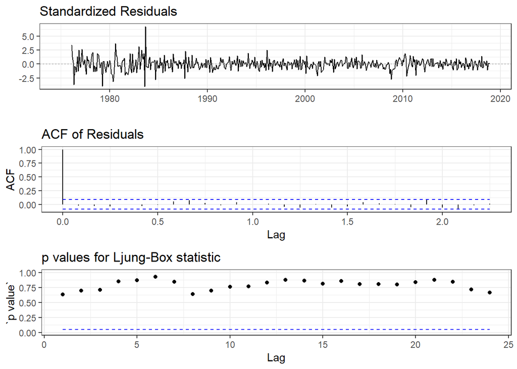

7. Use `auto.arima` to find the best model for $\log E_t$. Check the estimated model for adequacy - diagnose residuals using `ggtsdiag`.

```r
m1<- data_tbl_1 %>%
      tk_ts(select = lE, start = fstm1, frequency = 12) %>%
      auto.arima(ic = "aic", seasonal = TRUE,stationary = FALSE, stepwise = TRUE, approximation = TRUE)
m1
```

```
## Series: .
## ARIMA(1,1,2)(1,1,2)[12]
##
## Coefficients:
##          ar1      ma1     ma2    sar1     sma1     sma2
##       0.8904  -0.6168  0.1396  0.1074  -0.7864  -0.0123
## s.e.  0.0336   0.0543  0.0511  0.2491   0.2454   0.1876
##
## sigma^2 estimated as 5.924e-06:  log likelihood=2568.64
## AIC=-5123.28   AICc=-5123.06   BIC=-5093.57
```

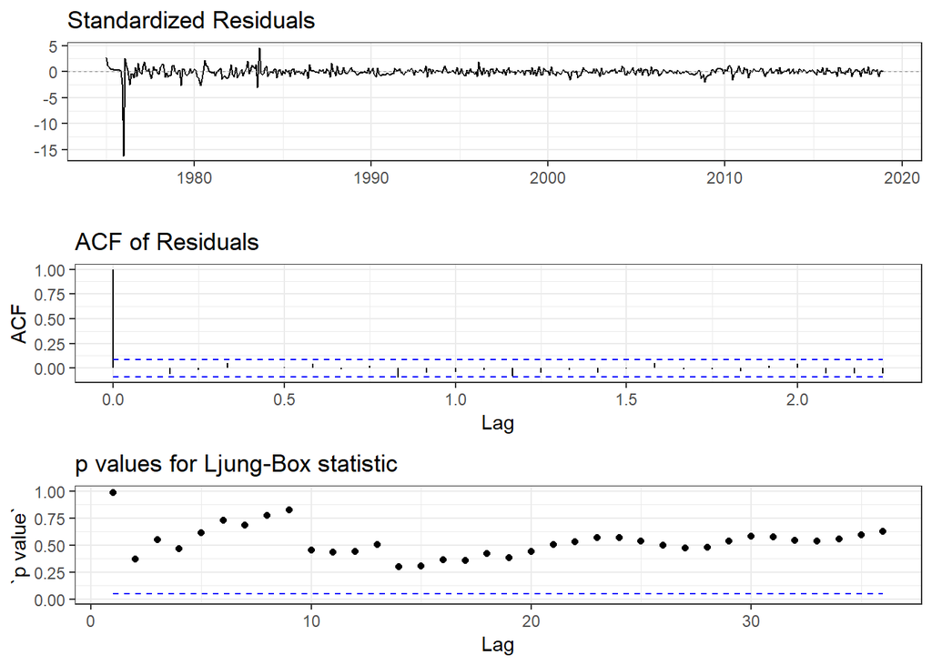

```r
ggtsdiag(m1,gof.lag=36)
```

8. Use `slide` from `tsibble` package to create a rolling scheme sequence of 1 period ahead forecasts for the prediction subsample 2015M1-2018M12 using the same model specification as in (g).

```r
      fstm1 <- 1975
      lstm1 <- 2015-(1/12)

      window.length <- data.tbl%>%
        filter(index <= as.yearmon(lstm1)) %>%
        nrow()

      tic()
      results <-
        data.tbl %>%
        mutate(yearm= yearmonth(index)) %>%
        as_tsibble(index = yearm) %>%                                        # covert to tsibble
        mutate(sarima.model = slide(lE, ~auto.arima(.x, ic = "aicc", seasonal = TRUE, approximation = TRUE, stepwise = TRUE),
                                    .size = window.length)) %>%             # estimate models
        filter(!is.na(sarima.model)) %>%
        mutate(sarima.coefs = map(sarima.model, tidy, conf.int = TRUE),
               sarima.fcst = map(sarima.model, (. %>% forecast(1) %>% sw_sweep())))
      toc()
```

```
## 10.97 sec elapsed
```

```r
      results
```

```
## # A tsibble: 49 x 12 [1M]
##    index  date      E    lE    dE     dlE1  dlE12 d2lE12_1      yearm
##    <S3:> <dbl>  <dbl> <dbl> <dbl>    <dbl>  <dbl>    <dbl>      <mth>
##  1 12月 ~ 16405 141326  11.9    -5 -3.54e-5 0.0217  1.78e-3  2014 12月
##  2 1月 2~ 16436 138511  11.8 -2815 -2.01e-2 0.0221  3.65e-4   2015 1月
##  3 2月 2~ 16467 139343  11.8   832  5.99e-3 0.0226  5.35e-4   2015 2月
##  4 3月 2~ 16495 140099  11.9   756  5.41e-3 0.0210 -1.60e-3   2015 3月
##  5 4月 2~ 16526 141283  11.9  1184  8.42e-3 0.0212  1.55e-4   2015 4月
##  6 5月 2~ 16556 142224  11.9   941  6.64e-3 0.0212  6.68e-5   2015 5月
##  7 6月 2~ 16587 142700  11.9   476  3.34e-3 0.0204 -8.66e-4   2015 6月
##  8 7月 2~ 16617 141747  11.9  -953 -6.70e-3 0.0214  1.05e-3   2015 7月
##  9 8月 2~ 16648 141939  11.9   192  1.35e-3 0.0200 -1.38e-3   2015 8月
## 10 9月 2~ 16679 142497  11.9   558  3.92e-3 0.0190 -1.00e-3   2015 9月
## # ... with 39 more rows, and 3 more variables: sarima.model <list>,
## #   sarima.coefs <list>, sarima.fcst <list>
```

1. Plot the forecast for $E_t$ from (h) together with its confidence intervals and the actual data for the period 2008M1-2018M12.

```r
#Forecasts
 fstm1 <- 1975
 lstm1 <- 2015-(1/12)
data.ts_4<- data.tbl%>%
  filter(index <= as.yearmon(lstm1)) %>%
  tk_ts(select = E, start=fstm1, frequency = 12)

# actual data
actual_tbl <-
  data.tbl %>%
  select(index, E) %>%
  mutate(key = "actual",
         date = as.Date(index)) %>%
  select(date, key, E) %>% filter(year(date) >= 2008)
actual_tbl
```

```
## # A tibble: 132 x 3
##    date       key         E
##    <date>     <chr>   <dbl>
##  1 2008-01-01 actual 136268
##  2 2008-02-01 actual 136787
##  3 2008-03-01 actual 137378
##  4 2008-04-01 actual 137914
##  5 2008-05-01 actual 138488
##  6 2008-06-01 actual 138682
##  7 2008-07-01 actual 137203
##  8 2008-08-01 actual 137094
##  9 2008-09-01 actual 137148
## 10 2008-10-01 actual 137442
## # ... with 122 more rows
```

```r
# estimate rolling SARIMA model, create 1 step ahead forecasts
PE_tbl_f_1 <-   results %>%
  select(yearm, sarima.fcst) %>%
  as_tibble() %>%
  unnest(sarima.fcst) %>%
  filter(key == "forecast") %>%
  mutate(yearm = yearm %m+% months(1) %>% yearmonth()) %>%
  mutate_at(vars(value, lo.80, lo.95, hi.80, hi.95), list(exp)) %>%
  rename(E = value) %>%
  select(yearm, key, E, lo.80, lo.95, hi.80, hi.95)

# forecast & actual data in a single tibble
f_a_tbl <- bind_rows(actual_tbl ,
                     PE_tbl_f_1 %>%
                       mutate(date= as.Date(yearm)) %>%
                       select(date, key, E, lo.80, lo.95, hi.80, hi.95), .id = NULL)
f_a_tbl
```

```
## # A tibble: 181 x 7
##    date       key         E lo.80 lo.95 hi.80 hi.95
##    <date>     <chr>   <dbl> <dbl> <dbl> <dbl> <dbl>
##  1 2008-01-01 actual 136268    NA    NA    NA    NA
##  2 2008-02-01 actual 136787    NA    NA    NA    NA
##  3 2008-03-01 actual 137378    NA    NA    NA    NA
##  4 2008-04-01 actual 137914    NA    NA    NA    NA
##  5 2008-05-01 actual 138488    NA    NA    NA    NA
##  6 2008-06-01 actual 138682    NA    NA    NA    NA
##  7 2008-07-01 actual 137203    NA    NA    NA    NA
##  8 2008-08-01 actual 137094    NA    NA    NA    NA
##  9 2008-09-01 actual 137148    NA    NA    NA    NA
## 10 2008-10-01 actual 137442    NA    NA    NA    NA
## # ... with 171 more rows
```

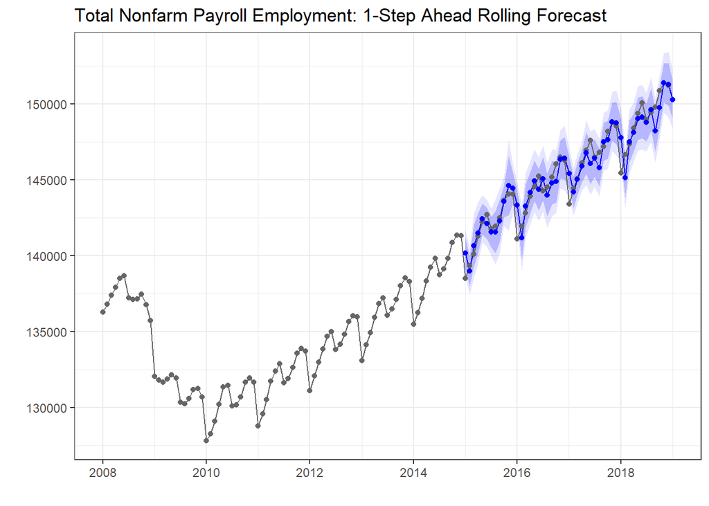

```r
# plot 1-month ahead rolling forecasts - levels
gf1<-f_a_tbl %>%
    filter(date >= "1975-01-01") %>%
    ggplot(aes(x =date, y = E, col = key, linetype = key)) +
         geom_ribbon(aes(ymin = lo.95, ymax = hi.95), linetype = "blank", fill = "blue", alpha = 0.1) +
         geom_ribbon(aes(ymin = lo.80, ymax = hi.80), linetype = "blank", fill = "blue", alpha = 0.2) +
         geom_line() +
         geom_point() +
        scale_color_manual(values = c("gray40","blue")) +
        scale_linetype_manual(values = c("solid","solid")) +
        labs(x = "", y = "",
        title = "Total Nonfarm Payroll Employment: 1-Step Ahead Rolling Forecast") +
         theme(legend.position = "none")
gf1
```

Comments: # from the result, it seems that this forecast performs well. The trend and seasonal pattern of the forecasts are close to the characteristics of the actual data.

10. Use the forecast for $E_t$ from (h) to construct the forecast for $\Delta E_t$, plot it together with the actual data.

```r
data.ts_5<- data.tbl%>%
  filter(index <= as.yearmon(lstm1)) %>%
  tk_ts(select = dE, start=fstm1, frequency = 12)

# actual data
actual_tbl_2 <-
  data.tbl %>%
  select(index, dE) %>%
  mutate(key = "actual",
         date = as.Date(index)) %>%
  select(date, key, dE) %>% filter(year(date) >= 2008)
actual_tbl_2
```

```
## # A tibble: 132 x 3
##    date       key       dE
##    <date>     <chr>  <dbl>
##  1 2008-01-01 actual -3029
##  2 2008-02-01 actual   519
##  3 2008-03-01 actual   591
##  4 2008-04-01 actual   536
##  5 2008-05-01 actual   574
##  6 2008-06-01 actual   194
##  7 2008-07-01 actual -1479
##  8 2008-08-01 actual  -109
##  9 2008-09-01 actual    54
## 10 2008-10-01 actual   294
## # ... with 122 more rows
```

```r
# estimate rolling SARIMA model, create 1 step ahead forecasts
PE_tbl_f_2 <-results %>%
  select(yearm, sarima.fcst) %>%
  as_tibble() %>%
  unnest(sarima.fcst) %>%
  filter(key == "forecast") %>%
  mutate(yearm = yearm %m+% months(1) %>% yearmonth()) %>%
  mutate_at(vars(value, lo.80, lo.95, hi.80, hi.95), list(exp)) %>%
  mutate(dE = value-lag(value)) %>%
  select(yearm, key, dE, lo.80, lo.95, hi.80, hi.95)

# forecast & actual data in a single tibble    ##combine the forecasts and actual data, then we can plot them together
f_a_tbl_2 <- bind_rows(actual_tbl_2,
                       PE_tbl_f_2 %>%
                       mutate(date= as.Date(yearm)) %>%
                       select(date, key, dE, lo.80, lo.95, hi.80, hi.95), .id = NULL)
f_a_tbl_2
```

```
## # A tibble: 181 x 7
##    date       key       dE lo.80 lo.95 hi.80 hi.95
##    <date>     <chr>  <dbl> <dbl> <dbl> <dbl> <dbl>
##  1 2008-01-01 actual -3029    NA    NA    NA    NA
##  2 2008-02-01 actual   519    NA    NA    NA    NA
##  3 2008-03-01 actual   591    NA    NA    NA    NA
##  4 2008-04-01 actual   536    NA    NA    NA    NA
##  5 2008-05-01 actual   574    NA    NA    NA    NA
##  6 2008-06-01 actual   194    NA    NA    NA    NA
##  7 2008-07-01 actual -1479    NA    NA    NA    NA
##  8 2008-08-01 actual  -109    NA    NA    NA    NA
##  9 2008-09-01 actual    54    NA    NA    NA    NA
## 10 2008-10-01 actual   294    NA    NA    NA    NA
## # ... with 171 more rows
```

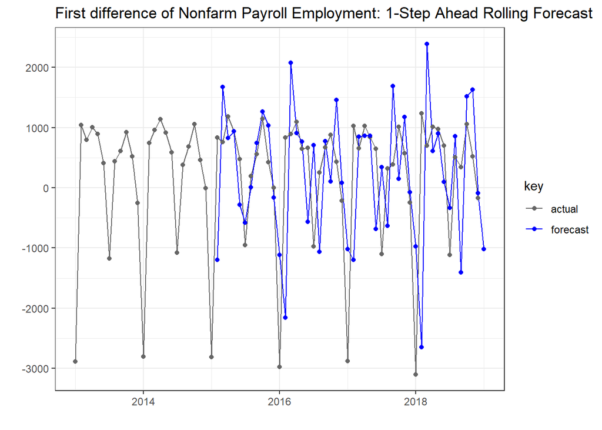

```r
# plot 1-month ahead rolling forecasts - levels
gf2<-f_a_tbl_2 %>%
  filter(date >= "2013-01-01") %>%
  ggplot(aes(x = date, y = dE, col = key, linetype = key)) +
  # geom_ribbon(aes(ymin = lo.95, ymax = hi.95), linetype = "blank", fill = "blue", alpha = 0.1) +
  # geom_ribbon(aes(ymin = lo.80, ymax = hi.80), linetype = "blank", fill = "blue", alpha = 0.2) +
  geom_line() +
  geom_point() +
  scale_color_manual(values = c("gray40","blue")) +
  scale_linetype_manual(values = c("solid","solid")) +
  labs(x = "", y = "",
       title = "First difference of Nonfarm Payroll Employment: 1-Step Ahead Rolling Forecast")
  #theme(legend.position = "none")
gf2
```

Comments: from the result, this forecast doesn’t perform well, it deviates from the actual data in a larger extent and it’s not consisent with the seasonality pattern of the actual data.

11. Construct and plot the forecast errors for $E_t$ and for $\Delta E_t$.

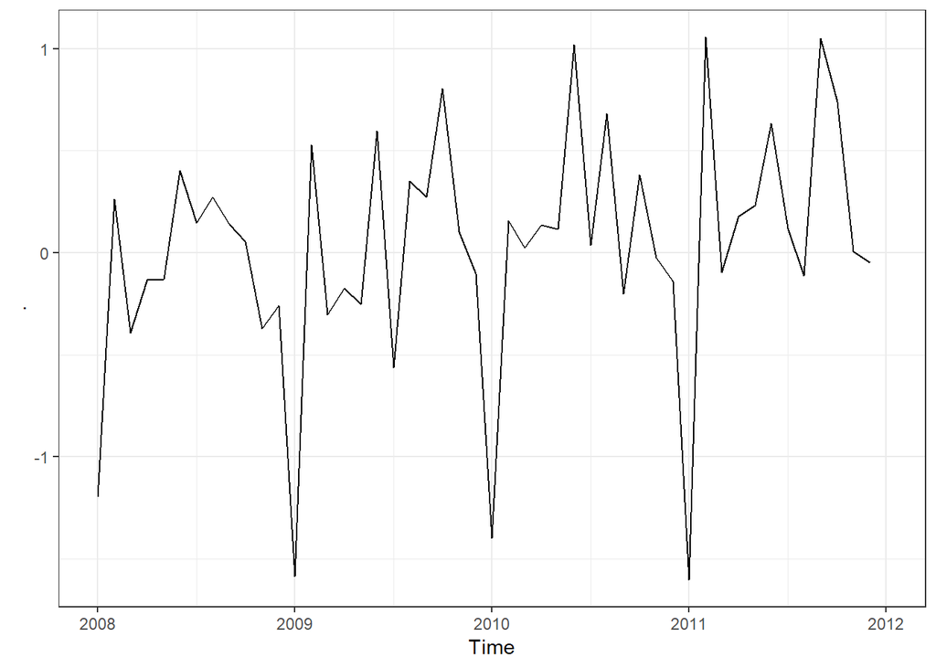

```r
#the forecast errors for $E_t$
f_a_tbl %>%
  select(date, key, E)%>%
  spread(key,E)%>%
  mutate(error=actual-forecast,
         percen_error=(actual-forecast)/actual*100) %>%
  filter(date >="2015-01-01") %>%
  tk_ts(select=percen_error, start=2008,frequency = 12)%>%
  autoplot()
```

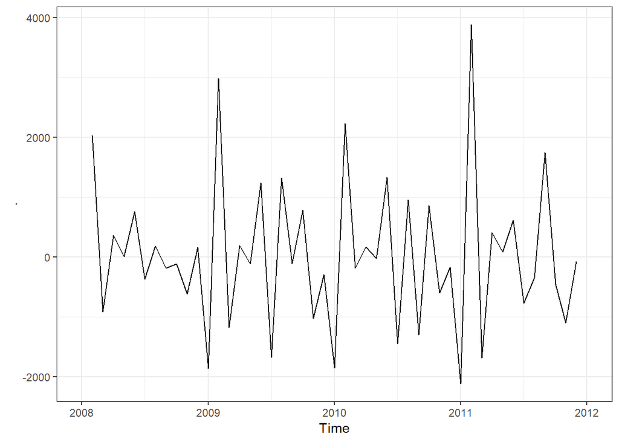

```r
#the forecast errors for $\Delta E_t$
f_a_tbl_2 %>%
  select(date, key, dE)%>%
  spread(key,dE)%>%
  mutate(error=actual-forecast) %>%
  filter(date >="2015-01-01") %>%
  tk_ts(select=error, start=2008,frequency = 12)%>%
  autoplot()    # note: it doesn't make sense to calculate percentage error here.
```